# How can a velocity with zero average push a flow?

From sine waves to momentum transport, with a reproducible experiment

Published

September 11, 2026

**A velocity fluctuation can average to zero and still carry momentum. If that transport varies from place to place, it contributes a force to the mean flow.** The reason is that momentum transport depends on products of velocities: reversing both factors leaves their product unchanged.

This answers a question left by the previous article. There we calculated the force needed to sustain a prescribed vortex. Some terms balanced, while others left a residual. Could additional fluid motion supply part of the missing transport even if its average velocity vanished?

That is the role of the oscillatory corrections in the proposed OpenAI construction. Its pulse families supply averaged radial fluxes of angular and axial momentum. [OpenAI, Section 2.2 and Proposition 7.5](https://cdn.openai.com/pdf/32d9f210-8b73-45e0-91bc-82a30aef8a9a/navier-stokes.pdf)

We will make the underlying mechanism visible in three steps. First, average a sine wave and its square. Then construct an incompressible velocity with a chosen average momentum flux. Finally, let its amplitude vary across space and calculate the resulting mean force, including the part that pressure can cancel. All examples use a dimensionless periodic square, so the algebra and the numerical checks can be inspected without a Navier–Stokes solver.

## Opposite motions need not cancel their transport

Imagine a fluid parcel moving upward while carrying more horizontal momentum than its surroundings. Another parcel moves downward while carrying less. The mean vertical velocity can be zero, but both motions contribute to the same net upward transport of horizontal momentum: in the second parcel, both deviations have the opposite sign.

For a fluctuation $\mathbf w=(w_x,w_y)$, that transport is measured by $w_xw_y$. The simplest arithmetic example is

$$\langle\sin\phi\rangle=0,\qquad
\langle\sin^2\phi\rangle=\frac12,$$

where the brackets mean a uniform average over one complete period. Cancellation of the first average says nothing about cancellation of the second.

Collect the velocity products in a matrix:

$$Q=\langle\mathbf w\otimes\mathbf w\rangle
=\begin{pmatrix}
\langle w_x^2\rangle&\langle w_xw_y\rangle\\
\langle w_yw_x\rangle&\langle w_y^2\rangle
\end{pmatrix}.$$

Here $Q$ is the momentum covariance per unit density. Its diagonal entries measure squared fluctuations; its off-diagonal entries measure correlated transport. In dimensional variables, $Q$ has units of velocity squared. Some engineering conventions call $-\rho Q$ the Reynolds stress. We retain the positive covariance definition and write the force sign explicitly.

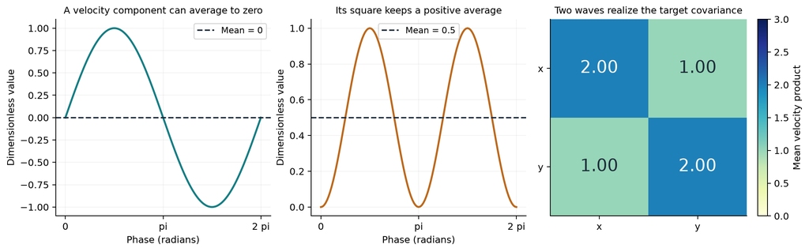

Figure 1: A sine has zero mean while its square has mean one half. The matrix on the right is the numerically averaged covariance of the two-wave example below, which matches its prescribed target. The scalar panels show the elementary averaging identity, not the two-component velocity field itself.

## Build a velocity with the stress we want

Choose the target

$$Q_{\rm target}=
\begin{pmatrix}2&1\\1&2\end{pmatrix}.$$

Can an incompressible velocity produce it? On $0\le x,y<2\pi$, take

$$\mathbf w=
\sqrt3\binom{1}{1}\sin[8(x-y)]
+\binom{1}{-1}\sin[9(x+y)].$$

Each wave’s velocity direction is perpendicular to its wavevector. For example, the first wave points along $(1,1)$ while its phase changes along $(1,-1)$. Their dot product is zero, giving $\nabla\cdot\mathbf w=0$ exactly.

Average over the full square. Each sine averages to zero, each squared sine averages to one half, and their cross product averages to zero because the two Fourier modes are different. Thus

$$\langle\mathbf w\rangle=0,\qquad
Q=\frac32
\begin{pmatrix}1&1\\1&1\end{pmatrix}
+\frac12
\begin{pmatrix}1&-1\\-1&1\end{pmatrix}
=Q_{\rm target}.$$

The factors $3$ and $1$ are the covariance eigenvalues. Changing these nonnegative weights changes the prescribed covariance within this two-direction family. The amplitudes are their square roots because the velocity product is quadratic.

This realizes a **global average**. It does not make the instantaneous product $\mathbf w(x,y)\otimes\mathbf w(x,y)$ constant at every point. Nor does a nonzero constant covariance by itself give a mean force: its spatial divergence is zero.

## A force requires a change in momentum flux

For an incompressible velocity, the nonlinear transport can be written as

$$(\mathbf u\cdot\nabla)\mathbf u
=\nabla\cdot(\mathbf u\otimes\mathbf u).$$

Split the velocity into its mean and fluctuation, $\mathbf u=\overline{\mathbf u}+\mathbf w$, with $\langle\mathbf w\rangle=0$. For an average that commutes with differentiation, averaging the momentum equation leaves the additional transport $\nabla\cdot Q$. Move it to the right-hand side and the force on the mean is

$$\boxed{\mathbf F_{\rm wave}=-\nabla\cdot Q.}$$

This is a force per unit mass. It expresses a familiar balance: a region gains momentum when more arrives than leaves. A constant flux has equal inflow and outflow. A changing flux can accelerate one region while decelerating another.

To demonstrate that change, we now average over $x$ **at fixed $y$**. The resulting covariance remains a function of $y$. This differs from the full-square average in the previous example.

## Give the oscillations a varying envelope

Let the amplitude be larger near $y=0$ and smaller near $y=\pi$:

$$a(y)=1+\epsilon\cos y,\qquad \epsilon=0.4.$$

Simply multiplying a divergence-free wave by $a(y)$ generally breaks incompressibility. A streamfunction avoids that problem. Define

$$\psi(x,y)=\frac{a(y)}k\cos[k(x+my)],
\qquad
\mathbf w=(\partial_y\psi,-\partial_x\psi),$$

with integers $k=8$ and $m=1$. The mixed derivatives cancel in the divergence. Expanding the velocity gives

$$w_x=\frac{a'}k\cos\phi-ma\sin\phi,\qquad
w_y=a\sin\phi,\qquad
\phi=k(x+my).$$

The term $a'\cos\phi/k$ is the small correction that preserves incompressibility. It matters even though the main oscillation looks nearly unchanged.

The average velocity is zero at every $y$. Averaging its products over $x$ gives the exact covariance

$$Q(y)=\frac{a^2}{2}
\begin{pmatrix}m^2&-m\\-m&1\end{pmatrix}
+\begin{pmatrix}(a')^2/(2k^2)&0\\0&0\end{pmatrix}.$$

Since this matrix depends only on $y$, the force uses the derivatives of its second column:

$$\mathbf F_{\rm wave}
=-\binom{\partial_yQ_{xy}}{\partial_yQ_{yy}}
=\binom{maa'}{-aa'}.$$

We have obtained a nonzero mean force from a velocity whose mean vanishes everywhere in the averaging coordinate.

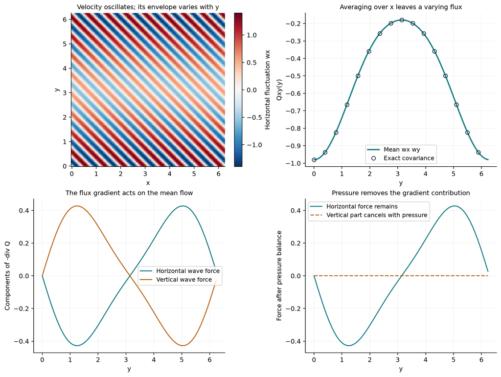

Figure 2: The horizontal velocity alternates in sign, with amplitude varying across height. Averaging over x leaves a spatially varying momentum flux. Differentiating that flux gives opposite horizontal and vertical force components in this example. A pressure contribution cancels the vertical component while the horizontal component remains. These are static fields on a dimensionless periodic square; no time evolution or particle trajectories are shown.

## Pressure can cancel some of the force

In incompressible flow, pressure balances gradient contributions. Here the vertical wave force is

$$-aa'=-\partial_y(a^2/2).$$

The mean pressure $p=-a^2/2$ contributes $-\nabla p=(0,aa')$ to the right-hand side. After adding it, the remaining force is

$$\mathbf F_{\rm remaining}=(maa',0).$$

This horizontal force varies with $y$. Its two-dimensional curl is

$$-m\big[(a')^2+aa''\big],$$

which is generally nonzero, so a pressure gradient cannot remove it. In the baseline calculation, its largest sampled magnitude is approximately **0.427** in the chosen dimensionless units. Its integral over the periodic square is zero: this transport redistributes momentum.

More generally, an isotropic covariance $q(\mathbf x)I$ contributes $-\nabla q$ and can be absorbed into pressure. The part that changes the incompressible mean velocity is the divergence-free part of $-\nabla\cdot Q$.

This calculation is a snapshot of momentum transport. Keeping the prescribed fluctuation field fixed in time would require its own dynamical balance; we have not constructed that balance or evolved a mean flow.

## Make sure the grid captures the oscillations

Uniform periodic samples integrate these resolved trigonometric products to floating-point accuracy. Spatial derivatives are evaluated with Fourier differentiation. The baseline uses $128^2$ samples, excludes the duplicated endpoint, and resolves both the carriers and their quadratic products.

| Check | Computed value |
| --- | --- |
| Constant target: relative covariance error | 1.02e-14 |
| Envelope: maximum mean-velocity component | 3.75e-16 |
| Envelope: maximum absolute divergence | 7.54e-13 |
| Envelope: maximum covariance error | 1.33e-15 |
| Mean force: error from differentiated covariance | 4.31e-14 |
| Mean force: error from direct transport | 4.1e-14 |

The force is checked in two ways: differentiate the averaged covariance, and separately calculate $(\mathbf w\cdot\nabla)\mathbf w$ before averaging. Both agree with the analytic expression.

A deliberately coarse $16^2$ grid gives approximately **94.9% relative covariance error** in the constant-target example. Its frequency-eight sine is sampled at its zeros, so that entire contribution is lost. A small numerical divergence does not rescue a velocity that was sampled incorrectly.

At $20^2$ samples the covariance average is already accurate, but the grid still cannot represent every quadratic Fourier mode. With the chosen carriers, their highest coordinate frequency is 18, requiring $N>36$ for full product resolution. An accurate average alone is therefore insufficient evidence that the entire nonlinear field is resolved.

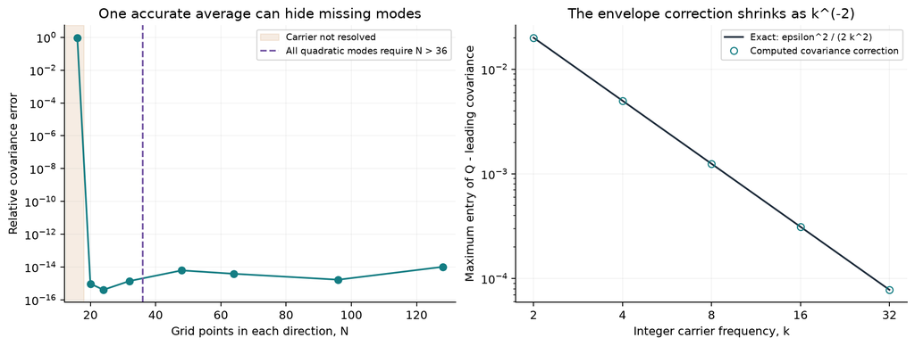

Figure 3: The covariance error is large on a grid that loses a carrier. Some finer grids reproduce the average even before resolving all quadratic modes. The right panel isolates a different effect: the exact covariance correction from the varying envelope decreases as the inverse square of carrier frequency.

The right panel shows a modelling correction, rather than numerical error. The maximum additional covariance entry is exactly $\epsilon^2/(2k^2)$, so doubling $k$ divides it by four. We use a resolved $256^2$ grid for that frequency scan. In this particular construction, the correction lies in $Q_{xx}(y)$ and contributes no divergence, so the exact mean force is independent of $k$.

## What restrictions does a realizable stress satisfy?

Every covariance is positive semidefinite:

$$\mathbf c^TQ\mathbf c
=\langle(\mathbf c\cdot\mathbf w)^2\rangle\ge0.$$

This permits negative off-diagonal entries, as our varying-envelope example demonstrates. It forbids a negative variance. Our two fixed wave directions impose a further restriction: their covariances can be combined only with nonnegative squared amplitudes.

The paper has an additional, specific admissibility condition. Its target is a two-component flux vector $(T_{r\theta},T_{rz})$, not a complete covariance matrix. Proposition 7.5 selects positive squared amplitudes from two pulse covariance directions; Equation (4.26) constrains the target direction through the background shear. Positive semidefiniteness alone does not check that condition. [OpenAI, Theorem 4.6(iii) and Proposition 7.5](https://cdn.openai.com/pdf/32d9f210-8b73-45e0-91bc-82a30aef8a9a/navier-stokes.pdf)

Our example establishes the averaging mechanism, exact incompressibility, and a mean force that survives pressure balance. Evaluating the paper’s actual stress and pulse amplitudes requires its joined background and pulse dynamics, which this toy does not supply.

The next question is dynamical: where can the oscillations obtain their energy, and why can viscosity eventually extinguish them? That motivates the next installment on a wave growing in a sheared flow and then decaying.

The executed notebook, parameters, CSV datasets, and source notes make the calculations and scope reproducible.